# IP WEEK 13

EZRA MAGETO

7/10/2021

# DEFINING THE QUESTION

### Kira Plastinina is a Russian brand that is sold through a defunct chain of retail stores in Russia, Ukraine, Kazakhstan, Belarus, China, Philippines, and Armenia. The brand’s Sales and Marketing team would like to understand their customer’s behavior from data that they have collected over the past year. More specifically, they would like to learn the characteristics of customer groups.

# METRICS OF SUCCESS

### 1.Perform clustering stating insights drawn from your analysis and visualizations.

# EXPERIMENTAL DESIGN

### You will create a Markdown which will comprise the following sections.

#### 1.Problem Definition

#### 2.Data Sourcing

#### 3.Check the Data

#### 4.Perform Data Cleaning

#### 5.Perform Exploratory Data Analysis (Univariate, Bivariate & Multivariate)

#### 6.Implement the Solution

#### 7.Challenge the Solution

#### 8.Follow up Questions

# 1.0 READING THE DATASET

```r
ecom<-read.csv("http://bit.ly/EcommerceCustomersDataset")
```

```r
##Previewing the top of the dataset
head(ecom)
```

```
##   Administrative Administrative_Duration Informational Informational_Duration
## 1              0                       0             0                      0
## 2              0                       0             0                      0
## 3              0                      -1             0                     -1
## 4              0                       0             0                      0
## 5              0                       0             0                      0
## 6              0                       0             0                      0
##   ProductRelated ProductRelated_Duration BounceRates ExitRates PageValues
## 1              1                0.000000  0.20000000 0.2000000          0
## 2              2               64.000000  0.00000000 0.1000000          0
## 3              1               -1.000000  0.20000000 0.2000000          0
## 4              2                2.666667  0.05000000 0.1400000          0
## 5             10              627.500000  0.02000000 0.0500000          0
## 6             19              154.216667  0.01578947 0.0245614          0
##   SpecialDay Month OperatingSystems Browser Region TrafficType
## 1          0   Feb                1       1      1           1
## 2          0   Feb                2       2      1           2
## 3          0   Feb                4       1      9           3
## 4          0   Feb                3       2      2           4
## 5          0   Feb                3       3      1           4
## 6          0   Feb                2       2      1           3
##         VisitorType Weekend Revenue
## 1 Returning_Visitor   FALSE   FALSE
## 2 Returning_Visitor   FALSE   FALSE
## 3 Returning_Visitor   FALSE   FALSE
## 4 Returning_Visitor   FALSE   FALSE
## 5 Returning_Visitor    TRUE   FALSE
## 6 Returning_Visitor   FALSE   FALSE
```

```r
##Previewing the bottom of the data

tail(ecom)
```

```
##       Administrative Administrative_Duration Informational
## 12325              0                       0             1
## 12326              3                     145             0
## 12327              0                       0             0
## 12328              0                       0             0
## 12329              4                      75             0
## 12330              0                       0             0
##       Informational_Duration ProductRelated ProductRelated_Duration BounceRates
## 12325                      0             16                 503.000 0.000000000
## 12326                      0             53                1783.792 0.007142857
## 12327                      0              5                 465.750 0.000000000
## 12328                      0              6                 184.250 0.083333333
## 12329                      0             15                 346.000 0.000000000
## 12330                      0              3                  21.250 0.000000000
##        ExitRates PageValues SpecialDay Month OperatingSystems Browser Region
## 12325 0.03764706    0.00000          0   Nov                2       2      1
## 12326 0.02903061   12.24172          0   Dec                4       6      1
## 12327 0.02133333    0.00000          0   Nov                3       2      1
## 12328 0.08666667    0.00000          0   Nov                3       2      1
## 12329 0.02105263    0.00000          0   Nov                2       2      3
## 12330 0.06666667    0.00000          0   Nov                3       2      1
##       TrafficType       VisitorType Weekend Revenue
## 12325           1 Returning_Visitor   FALSE   FALSE
## 12326           1 Returning_Visitor    TRUE   FALSE
## 12327           8 Returning_Visitor    TRUE   FALSE
## 12328          13 Returning_Visitor    TRUE   FALSE
## 12329          11 Returning_Visitor   FALSE   FALSE
## 12330           2       New_Visitor    TRUE   FALSE
```

# 1.1 EXPLORING THE DATASET

```r
#EXPLORING THE DATASET
##Viewing the dataset
View(ecom)
```

```r
##Checking the shape of the dataset
dim(ecom)
```

```
## [1] 12330    18
```

the dataset has 12330 rows and 18 columns

```r
##Checking information of the dataset

str(ecom)
```

```
## 'data.frame':    12330 obs. of  18 variables:
##  $ Administrative         : int  0 0 0 0 0 0 0 1 0 0 ...
##  $ Administrative_Duration: num  0 0 -1 0 0 0 -1 -1 0 0 ...
##  $ Informational          : int  0 0 0 0 0 0 0 0 0 0 ...
##  $ Informational_Duration : num  0 0 -1 0 0 0 -1 -1 0 0 ...
##  $ ProductRelated         : int  1 2 1 2 10 19 1 1 2 3 ...
##  $ ProductRelated_Duration: num  0 64 -1 2.67 627.5 ...
##  $ BounceRates            : num  0.2 0 0.2 0.05 0.02 ...
##  $ ExitRates              : num  0.2 0.1 0.2 0.14 0.05 ...
##  $ PageValues             : num  0 0 0 0 0 0 0 0 0 0 ...
##  $ SpecialDay             : num  0 0 0 0 0 0 0.4 0 0.8 0.4 ...
##  $ Month                  : chr  "Feb" "Feb" "Feb" "Feb" ...
##  $ OperatingSystems       : int  1 2 4 3 3 2 2 1 2 2 ...
##  $ Browser                : int  1 2 1 2 3 2 4 2 2 4 ...
##  $ Region                 : int  1 1 9 2 1 1 3 1 2 1 ...
##  $ TrafficType            : int  1 2 3 4 4 3 3 5 3 2 ...
##  $ VisitorType            : chr  "Returning_Visitor" "Returning_Visitor" "Returning_Visitor" "Returning_Visitor" ...
##  $ Weekend                : logi  FALSE FALSE FALSE FALSE TRUE FALSE ...
##  $ Revenue                : logi  FALSE FALSE FALSE FALSE FALSE FALSE ...
```

```r
##checking the column names of the dataset

colnames(ecom)
```

```
##  [1] "Administrative"          "Administrative_Duration"
##  [3] "Informational"           "Informational_Duration"
##  [5] "ProductRelated"          "ProductRelated_Duration"
##  [7] "BounceRates"             "ExitRates"
##  [9] "PageValues"              "SpecialDay"
## [11] "Month"                   "OperatingSystems"
## [13] "Browser"                 "Region"
## [15] "TrafficType"             "VisitorType"
## [17] "Weekend"                 "Revenue"
```

```r
##Checking the datatypes of the dataset
class(ecom)
```

```
## [1] "data.frame"
```

```r
sapply(ecom,class)
```

```
##          Administrative Administrative_Duration           Informational
##               "integer"               "numeric"               "integer"
##  Informational_Duration          ProductRelated ProductRelated_Duration
##               "numeric"               "integer"               "numeric"
##             BounceRates               ExitRates              PageValues
##               "numeric"               "numeric"               "numeric"
##              SpecialDay                   Month        OperatingSystems
##               "numeric"             "character"               "integer"
##                 Browser                  Region             TrafficType
##               "integer"               "integer"               "integer"
##             VisitorType                 Weekend                 Revenue
##             "character"               "logical"               "logical"
```

```r
##Important features
ecomm <- ecom[, c(1,2,3,4,5,6,7,8,9,10)]
names(ecomm)
```

```
##  [1] "Administrative"          "Administrative_Duration"
##  [3] "Informational"           "Informational_Duration"
##  [5] "ProductRelated"          "ProductRelated_Duration"
##  [7] "BounceRates"             "ExitRates"
##  [9] "PageValues"              "SpecialDay"
```

# 2.0 CLEANING THE DATASET

```r
#DATA CLEANING
##Checking for missing values

sum(is.na(ecomm))
```

```
## [1] 112
```

```r
##Dealing with missing values
ecomm<-na.omit(ecomm)
sum(is.na(ecomm))
```

```
## [1] 0
```

```r
##Checking for duplicates
sum(duplicated(ecomm))
```

```
## [1] 751
```

```r
##Dealing with duplicates
###To deal with duplicates i pick the non duplicated data
ecomm = ecomm[!duplicated(ecomm), ]
dim(ecomm)
```

```
## [1] 11565    10
```

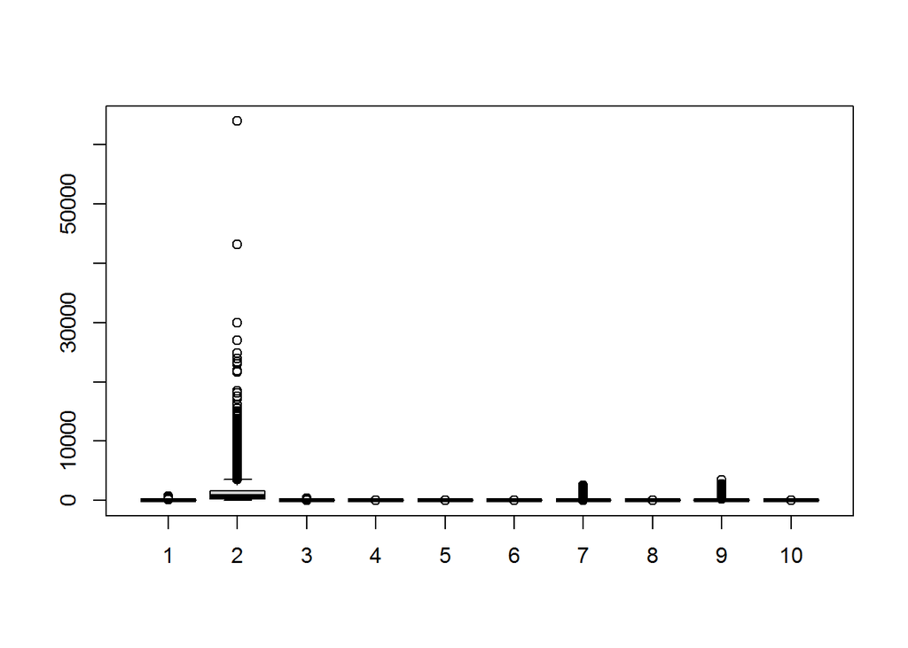

```r
##Checking for outliers
product_related<-ecomm$ProductRelated
product_related_duration<-ecomm$ProductRelated_Duration
page_values<-ecomm$PageValues
Administrative<-ecomm$Administrative
Administrative_Duration<-ecomm$Administrative_Duration
Informational<-ecomm$Informational
Informational_Duration<-ecomm$Informational_Duration
BounceRates<-ecomm$BounceRates
ExitRates<-ecomm$ExitRates
SpecialDay<-ecomm$SpecialDay
boxplot(product_related,product_related_duration,page_values,SpecialDay,ExitRates,BounceRates,Informational_Duration,Informational,Administrative_Duration,Administrative)
```

the dataset contains some outliers in the Product Related Duration feature

# 2.1 EXPLORATORY DATA ANALYSI

```r
#EXPLORATORY DATA ANALYSIS
##Univariate Analysis
####Summary of the descriptive statistics
summary(ecom)
```

```
##  Administrative   Administrative_Duration Informational
##  Min.   : 0.000   Min.   :  -1.00         Min.   : 0.000
##  1st Qu.: 0.000   1st Qu.:   0.00         1st Qu.: 0.000
##  Median : 1.000   Median :   8.00         Median : 0.000
##  Mean   : 2.318   Mean   :  80.91         Mean   : 0.504
##  3rd Qu.: 4.000   3rd Qu.:  93.50         3rd Qu.: 0.000
##  Max.   :27.000   Max.   :3398.75         Max.   :24.000
##  NA's   :14       NA's   :14              NA's   :14
##  Informational_Duration ProductRelated   ProductRelated_Duration
##  Min.   :  -1.00        Min.   :  0.00   Min.   :   -1.0
##  1st Qu.:   0.00        1st Qu.:  7.00   1st Qu.:  185.0
##  Median :   0.00        Median : 18.00   Median :  599.8
##  Mean   :  34.51        Mean   : 31.76   Mean   : 1196.0
##  3rd Qu.:   0.00        3rd Qu.: 38.00   3rd Qu.: 1466.5
##  Max.   :2549.38        Max.   :705.00   Max.   :63973.5
##  NA's   :14             NA's   :14       NA's   :14
##   BounceRates         ExitRates         PageValues        SpecialDay
##  Min.   :0.000000   Min.   :0.00000   Min.   :  0.000   Min.   :0.00000
##  1st Qu.:0.000000   1st Qu.:0.01429   1st Qu.:  0.000   1st Qu.:0.00000
##  Median :0.003119   Median :0.02512   Median :  0.000   Median :0.00000
##  Mean   :0.022152   Mean   :0.04300   Mean   :  5.889   Mean   :0.06143
##  3rd Qu.:0.016684   3rd Qu.:0.05000   3rd Qu.:  0.000   3rd Qu.:0.00000
##  Max.   :0.200000   Max.   :0.20000   Max.   :361.764   Max.   :1.00000
##  NA's   :14         NA's   :14
##     Month           OperatingSystems    Browser           Region
##  Length:12330       Min.   :1.000    Min.   : 1.000   Min.   :1.000
##  Class :character   1st Qu.:2.000    1st Qu.: 2.000   1st Qu.:1.000
##  Mode  :character   Median :2.000    Median : 2.000   Median :3.000
##                     Mean   :2.124    Mean   : 2.357   Mean   :3.147
##                     3rd Qu.:3.000    3rd Qu.: 2.000   3rd Qu.:4.000
##                     Max.   :8.000    Max.   :13.000   Max.   :9.000
##
##   TrafficType    VisitorType         Weekend         Revenue
##  Min.   : 1.00   Length:12330       Mode :logical   Mode :logical
##  1st Qu.: 2.00   Class :character   FALSE:9462      FALSE:10422
##  Median : 2.00   Mode  :character   TRUE :2868      TRUE :1908
##  Mean   : 4.07
##  3rd Qu.: 4.00
##  Max.   :20.00
##
```

From the descriptive statistics weekdays had the most numbers visiting the site Many people who visited the site did not generate any revenue for the brand. Only 1908 out of 12330 contributed to revenue addition for the brand.

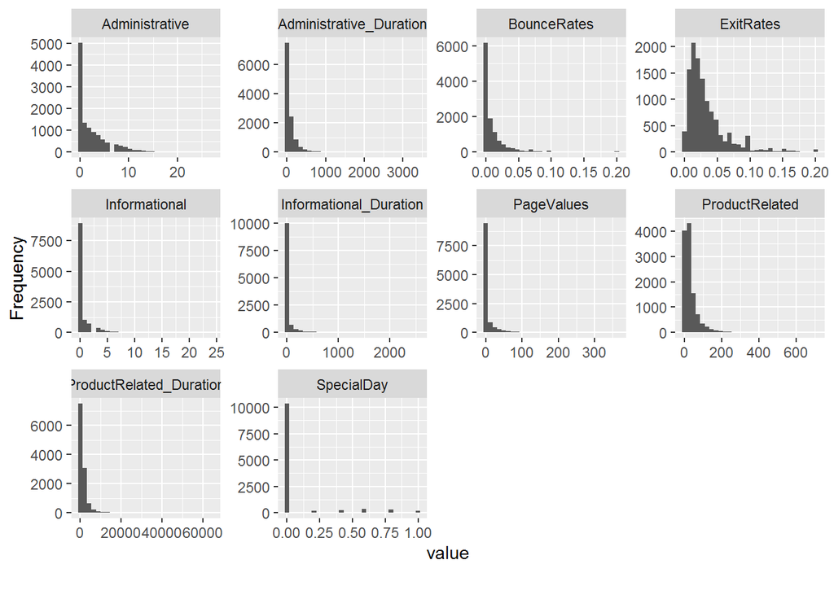

```r
#Plotting Histogram of selected features
library(DataExplorer)
plot_histogram(ecomm)
```

there is a positive skew in the distribution Of the features

```r
#creating bar plots for all categorical column
month_table <- table(ecom$Month)
os_table <- table(ecom$OperatingSystems)
browser_table <- table(ecom$Browser)
region_table <- table(ecom$Region)
traffic_table <- table(ecom$TrafficType)
visitor_table <- table(ecom$VisitorType)
weekend_table <- table(ecom$Weekend)
revenue_table <- table(ecom$Revenue)
```

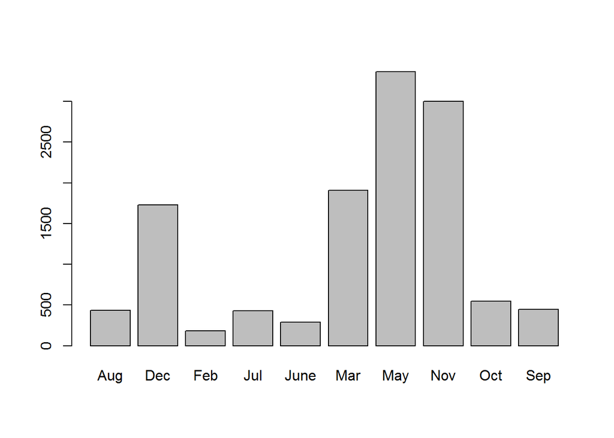

```r
#creating barplot for month
barplot(month_table)
```

```r
##the month of May had the most visits to the site while February was the least visited
```

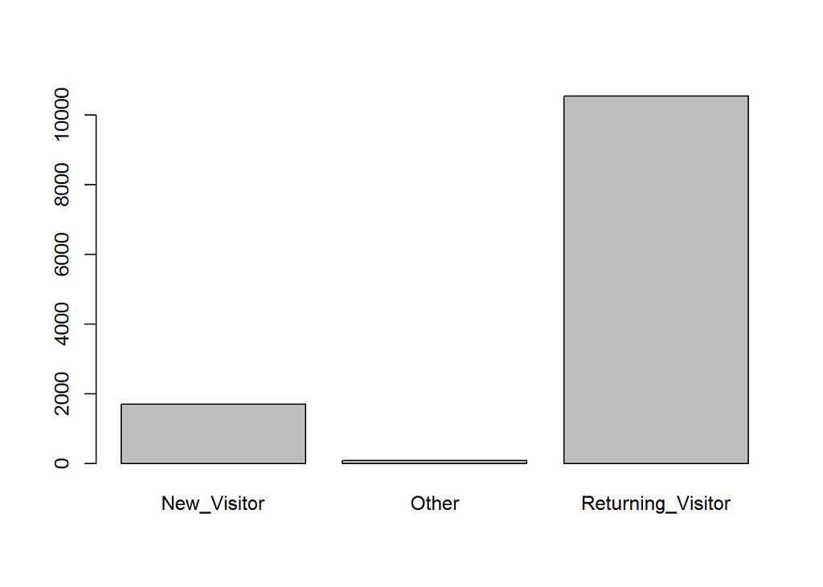

```r
#Barplot indicating visitor type
barplot(visitor_table)
```

returning visitors form the majority of of the visitor type

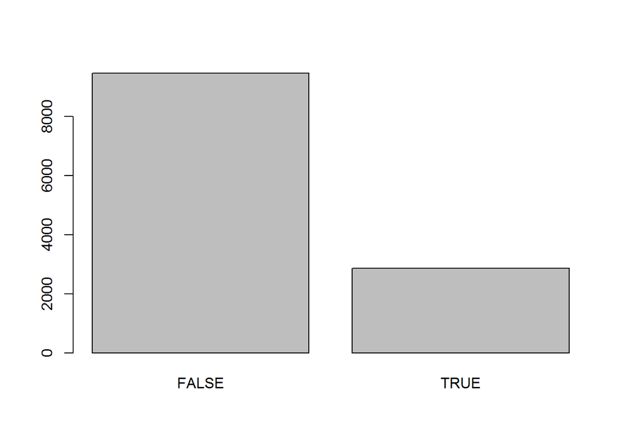

```r
#weekend barplot
barplot(weekend_table)
```

the site is mostly visited during the weekdays

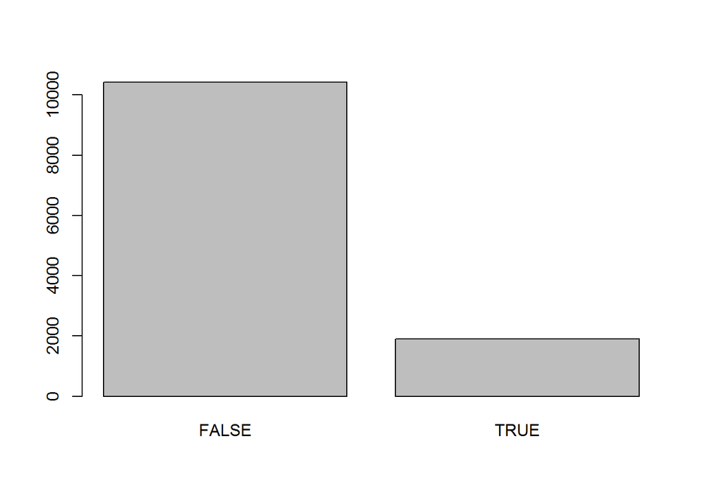

```r
#revenue barplot
barplot(revenue_table)
```

individuals who visit the site and generate revenue are less.Majority of the people visit the site and don’t generate any revenue

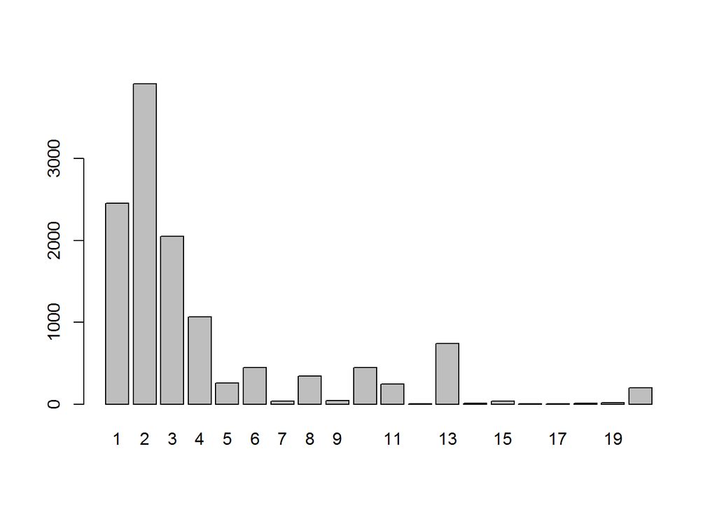

```r
#barplot on traffictype
barplot(traffic_table)
```

type 2 traffic is the highest followed by type 1 traffic

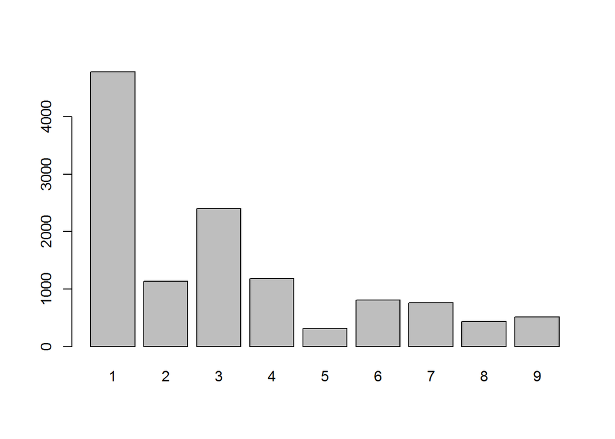

```r
#bar on region
barplot(region_table)
```

```r
#Bivariate Analysis
##getting the covariance
page_values<-ecomm$PageValues
product_related<-ecomm$ProductRelated

cov(page_values,product_related)
```

```
## [1] 36.97492
```

```r
##correlation
page_values<-ecomm$PageValues
product_related<-ecomm$ProductRelated
cor(page_values,product_related)
```

```
## [1] 0.04279685
```

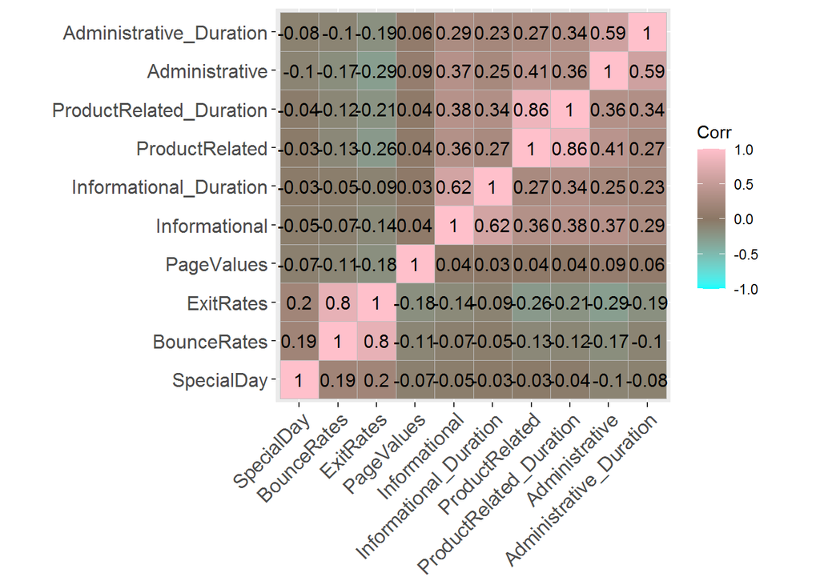

```r
#correlation plot
library(ggcorrplot)
library(dplyr)
corr = round(cor(select_if(ecomm, is.numeric)), 4)
ggcorrplot(corr, hc.order = T, ggtheme = ggplot2::theme_grey,
   colors = c("cyan", "peachpuff4", "pink"), lab = T)
```

there is a high correlation between the bounce rate and the exit rate

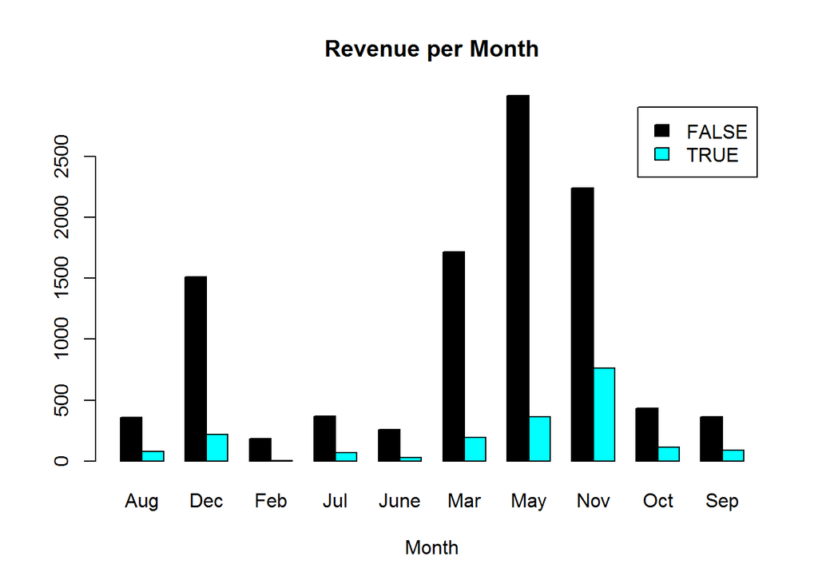

```r
##plotting revenue per month

rev_month <- table(ecom$Revenue, ecom$Month)
barplot(rev_month, main = "Revenue per Month", col = c("black", "cyan"), beside = TRUE,
        legend = rownames(rev_month), xlab = "Month")
```

November returned the highest number of revenue

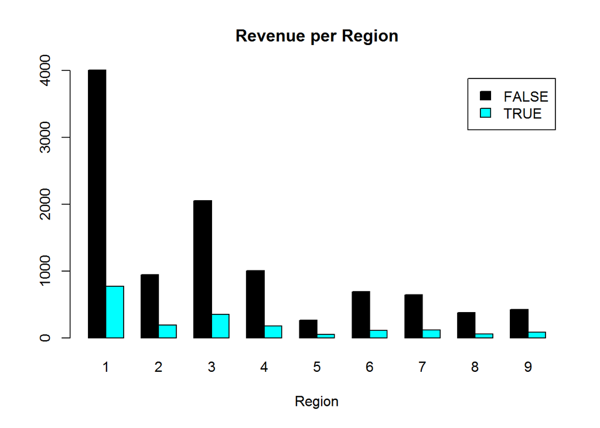

```r
##plotting revenue per region

rev_region <- table(ecom$Revenue, ecom$Region)
barplot(rev_region, main = "Revenue per Region", col = c("black", "cyan"), beside = TRUE,
        legend = rownames(rev_region), xlab = "Region")
```

region 1 returned more revenue with region 5 being the least

# 3.0 IMPLEMENTING THE SOLUTION

## K-MEANS CLUSTERING

#### Normalizing the required features

```r
normalize <- function(x){
  return ((x-min(x)) / (max(x)-min(x)))
}
ecomm$ProductRelated<- normalize(ecomm$ProductRelated)
ecomm$ProductRelated_Duration<- normalize(ecomm$ProductRelated_Duration)
ecomm$PageValues<- normalize(ecomm$PageValues)

head(ecomm)
```

```
##   Administrative Administrative_Duration Informational Informational_Duration
## 1              0                       0             0                      0
## 2              0                       0             0                      0
## 3              0                      -1             0                     -1
## 4              0                       0             0                      0
## 5              0                       0             0                      0
## 6              0                       0             0                      0
##   ProductRelated ProductRelated_Duration BounceRates ExitRates PageValues
## 1    0.001418440            1.563122e-05  0.20000000 0.2000000          0
## 2    0.002836879            1.016029e-03  0.00000000 0.1000000          0
## 3    0.001418440            0.000000e+00  0.20000000 0.2000000          0
## 4    0.002836879            5.731448e-05  0.05000000 0.1400000          0
## 5    0.014184397            9.824223e-03  0.02000000 0.0500000          0
## 6    0.026950355            2.426226e-03  0.01578947 0.0245614          0
##   SpecialDay
## 1          0
## 2          0
## 3          0
## 4          0
## 5          0
## 6          0
```

```r
####selecting necesarry columns
ecomm1<-ecomm[c(5,6,9)]
colnames(ecomm1)
```

```
## [1] "ProductRelated"          "ProductRelated_Duration"
## [3] "PageValues"
```

```r
#

# Applying the K-means clustering algorithm with number of centroids(k)=3
result<- kmeans(ecomm1,3)
# Previewing the no. of records in each cluster
result$size
```

```
## [1] 10021   658   886
```

```r
#value of cluster center datapoint
result$centers
```

```
##   ProductRelated ProductRelated_Duration  PageValues
## 1     0.03315973              0.01381340 0.006545849
## 2     0.04379055              0.01881582 0.187263442
## 3     0.21702768              0.08981467 0.013440616
```

```r
#cluster vector showing each record
result$cluster
```

[output not shown]

[output cut: 1765 more lines]

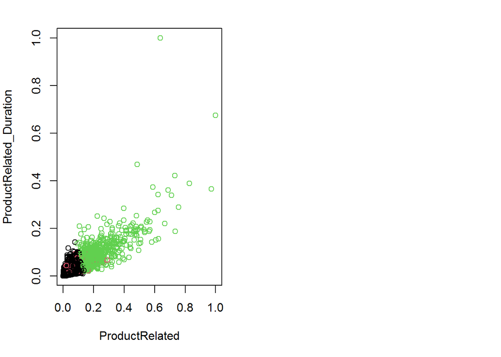

```r
#clustering result visualization
par(mfrow = c(1,2), mar = c(5,4,2,2))
#plotting to see how product related duration and product related have been distributed
plot(ecomm1[,1:2], col = result$cluster)
```

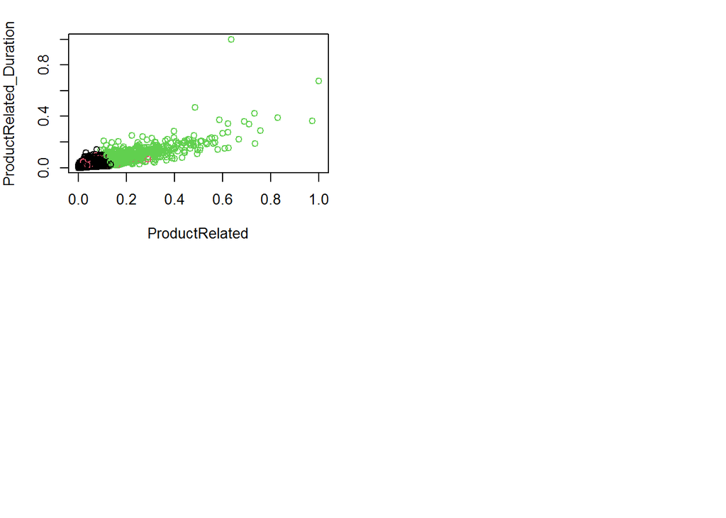

```r
#verifying the results of clustering
par(mfrow = c(2,2), mar = c(5,4,2,2))
#plotting product related duration and product related
plot(ecomm1[c(1,2)], col = result$cluster)
```

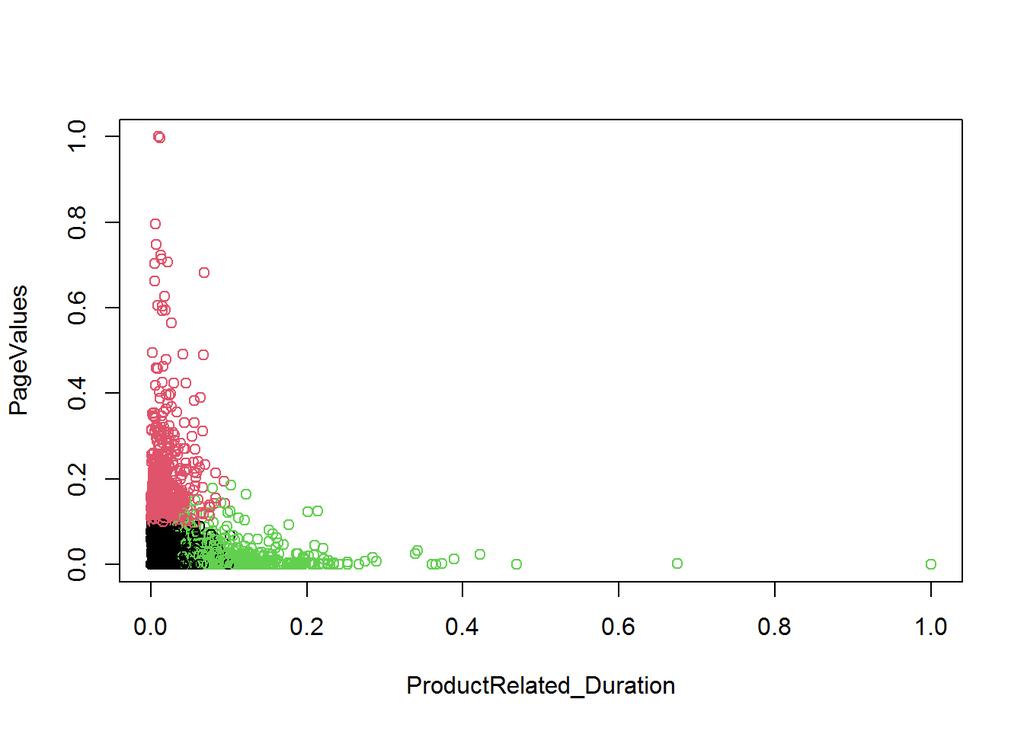

```r
#plotting page values and product related duration to check the distribution
plot(ecomm1[c(2,3)], col = result$cluster)
```

```r
#implementing with class attribute 'revenue'
ecomm1.class<- ecom[, "Revenue"]
```

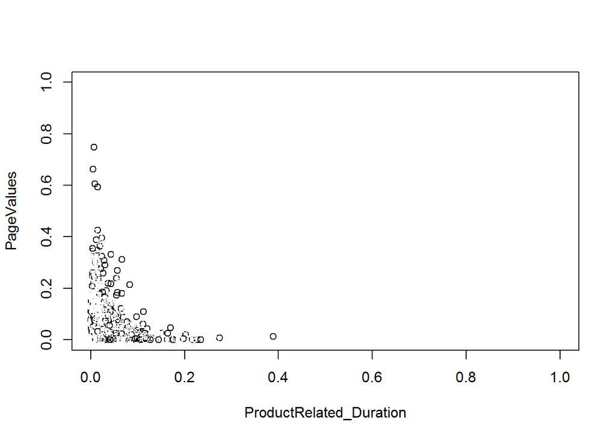

```r
plot(ecomm1[c(2,3)], col = ecomm1.class)
```

```r
#HIERARCHICAL CLUSTERING
#scaling the data
ecomm1<-scale(ecomm1)
head(ecomm1)
```

```
##   ProductRelated ProductRelated_Duration PageValues
## 1     -0.7240185              -0.6528458 -0.3285811
## 2     -0.7019008              -0.6200344 -0.3285811
## 3     -0.7240185              -0.6533584 -0.3285811
## 4     -0.7019008              -0.6514786 -0.3285811
## 5     -0.5249592              -0.3311408 -0.3285811
## 6     -0.3258999              -0.5737824 -0.3285811
```

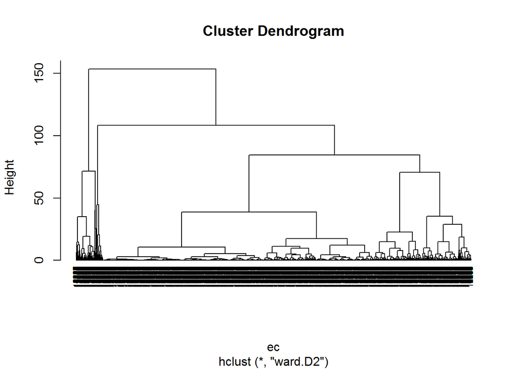

```r
#computing the euclidean distance
ec<-dist(ecomm1,method = "euclidean")
#performing hierarchical clustering
HC<-hclust(ec,method = "ward.D2")
#plotting the dendrogram
plot(HC,cex=0.6,hang= -1)
```

# 4.0 CONCLUSION

### Majority of the people visit the site during the weekdays

### Majority of people visit the site but don’t generate revenue

# 5.0 RECOMMENDATION

### Provide incentives to returning visitors to attract more new visitors